# Web Interface

In order to give an alternative interface for `simrel-m`, we have created a shiny app which allows users to input the simulation parameters through different input fields. Figure 1 shows a screenshot of the application. The application contains three main sections through which the user can interact with this simulation approach. A random seed can be selected using section Figure 1 (a) so that a particular set of data can be re-simulated if needed. Figure 1 (b) has all the input panels where the user dependent parameters for simulation can be entered. Here the user also has the option to simulate univariate (uses `simrel` package in CRAN), bivariate (not yet available in CRAN) and multivariate simulation (`simrel-m`). In addition, a simulated R-object is comprised by the simulated data can be download as `Rdata` format (section (e) in Figure 1). The object holds the simulated data along with other properties such as coefficient of determination for each response, true regression coefficients and rotation matrices.

All `simrel-m` parameters can be entered using a simple user interface where a vectors are separated with comma(,) and lists are separated with semicolon(;). For instance, the relevant position discussed in the implementation section of this paper can be entered as `1, 6; 2, 5; 3, 4` which is equivalent to R syntax `list(c(1, 6), c(2, 5), c(3, 4))`.

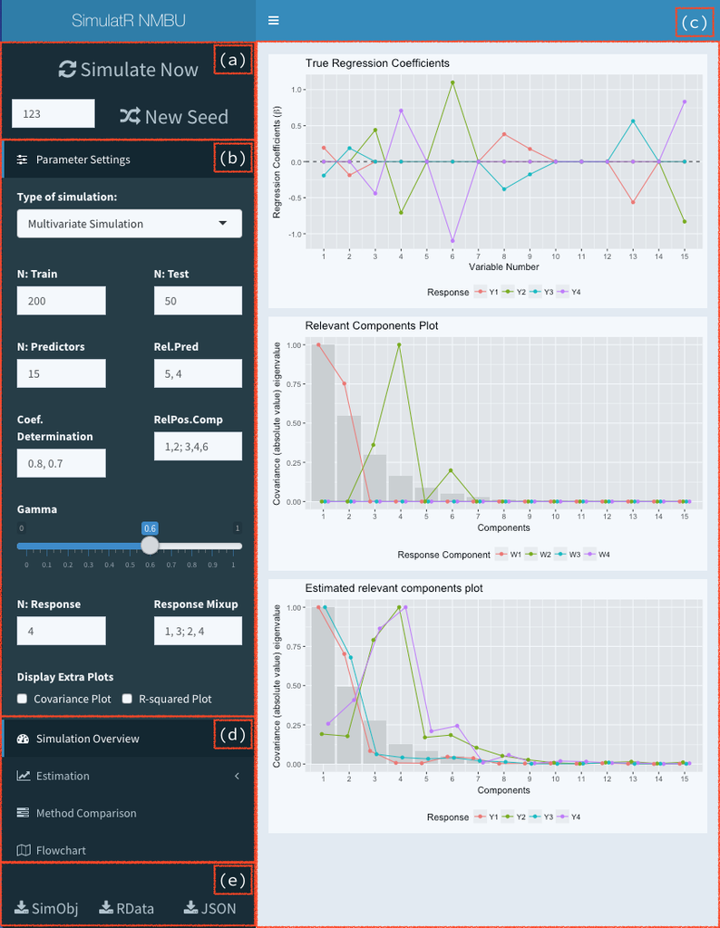

Figure 1: Application interface of `simulatr`. (a) Seed and simulation button (b) Parameter control panel (c) Properties of simulated data (d) Additional analysis (e) Download option of simulated data

The application not only allows users to simulate data, but also gives some insight into simulated data properties. The example used in the screenshot has simulated 200 training and 50 test samples with 15 predictor and 4 response variables. There are two latent variables (response components) that completely span the informative response space. Five predictor variables are relevant for the first response component and explains 80 percent of the variation in $\mathbf{x}$. In addition, the first and second predictor components span the same space as spanned by these five relevant predictors. Similarly, another set of four predictor variables are relevant for second response component and explains 70 percent of the variation. Here, third, fourth and sixth predictor components span the same space as spanned by these four relevant predictors. Further, the first response component is rotated together with a normally distributed random vector to obtain first and third response variable and second response components are rotated together with another normally distributed random vector to obtain second and fourth response variable.

Section (c) in Figure 1 contains three plots – a) true regression coefficients b) relevant components and c) estimated relevant components. In the first plot we can see that predictor variables (1, 2, 8, 9 and 13) are relevant for the first and third response variable by their non-zero coefficients, whereas predictor variables (3, 4, 6 and 15) are relevant for the second and fourth response variable. The second plot shows the covariances between the response components and the predictor components along with the corresponding eigenvalues in the background (bar plot). In the plot the absolute value of the covariances after scaling with the largest covariance are shown. As in our parameter setting, the plot shows that first and second predictor components have non-zero covariance with first response component and third, fourth and sixth predictor components have non-zero covariance with second response component. The third plot is the estimated covariance between predictor components and the response variables, for the simulated data. Since the first and third response components are rotated together, in the plot, the covariance between predictor components and first and third response variable is following similar pattern. This also suggests that the predictor components which were relevant for first response components gets relevant for first and third response variables after rotation.

Along with these main sections, section (d) in the figure contains additional analysis performed with the simulated data such as its estimation with different methods. This section is intended for educational purposes to show how changing the data properties influences the performances of different estimation and prediction methods.

Many scientific studies (Helland et al. 2012; Sæbø et al. 2008; Cook and Zhang 2015) are using simulated data in order to compare their findings with others or assess its properties. In many of these situations, a user-friendly and versitle simulation tool like `simrel-m` can play an important role. L. E. Gangsei, Almøy, and Sæbø (2016); L. Gangsei, Almøy, and Sæbø (2016); and Sæbø, Almøy, and Helland (2015) are some examples where the univariate and bivariate form of `simrel` have been used for such purposes.

Cook, R Dennis, and Xin Zhang. 2015. “Simultaneous Envelopes for Multivariate Linear Regression.” *Technometrics* 57 (1). Taylor & Francis: 11–25.

Gangsei, Lars Erik, Trygve Almøy, and Solve Sæbø. 2016. “Theoretical Evaluation of Prediction Error in Linear Regression with a Bivariate Response Variable Containing Missing Data.” *Communications in Statistics-Theory and Methods*, no. just-accepted. Taylor & Francis.

Gangsei, LE, T Almøy, and S Sæbø. 2016. “Linear Regression with Bivariate Response Variable Containing Missing Data.” *An Empirical Bayes Strategy to Increase Prediction Precision. Submitted Manuscript to Communications in Statistics–Simulation and Computation*.

Helland, Inge S, Solve Saebø, Ha Tjelmeland, and others. 2012. “Near Optimal Prediction from Relevant Components.” *Scandinavian Journal of Statistics* 39 (4). Wiley Online Library: 695–713.

Sæbø, Solve, Trygve Almøy, and Inge S Helland. 2015. “Simrel – a Versatile Tool for Linear Model Data Simulation Based on the Concept of a Relevant Subspace and Relevant Predictors.” *Chemometrics and Intelligent Laboratory Systems*. Elsevier.

Sæbø, Solve, Trygve Almøy, Arnar Flatberg, Are H Aastveit, and Harald Martens. 2008. “LPLS-Regression: A Method for Prediction and Classification Under the Influence of Background Information on Predictor Variables.” *Chemometrics and Intelligent Laboratory Systems* 91 (2). Elsevier: 121–32.